# R3.01 - Environnement économique: Economie financière

Chapitre 3 : Bulles et crises financières

Thomas Delcey

thomas.delcey@ube.fr

Université de Bourgogne Europe

### Le problème du chapitre

Au chapitre 1 et 2, on a vu le système financier, ces acteurs et ces principales fonctions (financement, gestion du risque). Pour l’instant, nous n’en avons dit que du bien. Mais ce système peut dysfonctionner et provoquer des crises financières.

**Le problème du chapitre**

Qu’est-ce qu’une crise financière ? Pourquoi se produisent-elles ?

### Les fonctions du système financier

### La navette Challenger, 28 janvier 1986

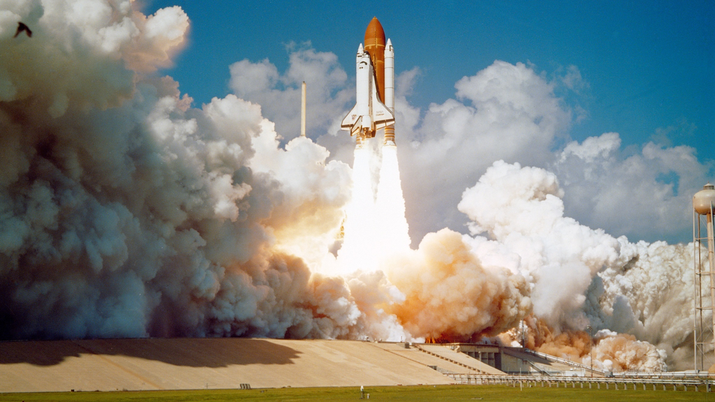

### Les quatre fournisseurs de la NASA

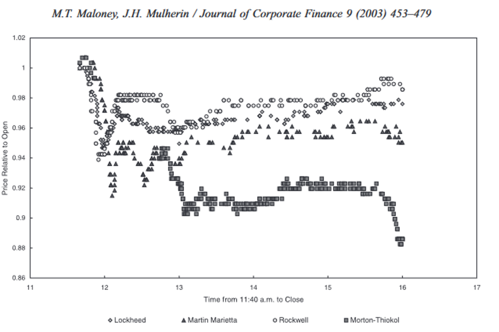

### L’efficience des marchés financiers

1. Les traders sont extrêmement bien informés.
2. Il y a des erreurs: certains actifs sont sous-évalués et d’autres sur-évalués.
3. Ces erreurs représentent des opportunités de profits faciles et sont rapidement exploitées.
4. En conséquence, le prix des actifs reflète toujours l’information disponible.

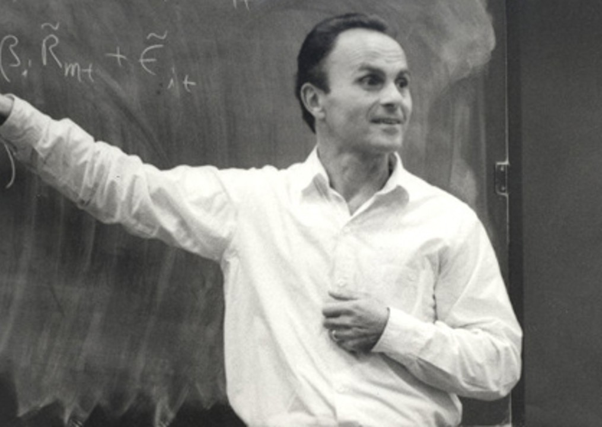

Eugene Fama, économiste américain

### Conséquences de l’efficience des marchés financiers

1. Il est impossible de “battre le marché” de manière systématique.
2. La meilleur stratégie est l’investissement passif, principalement via les ETF.
3. Il n’y jamais de sous-évaluations ou de sur-évaluations persistantes.

### Le S&P 500 de 1940 à 2025

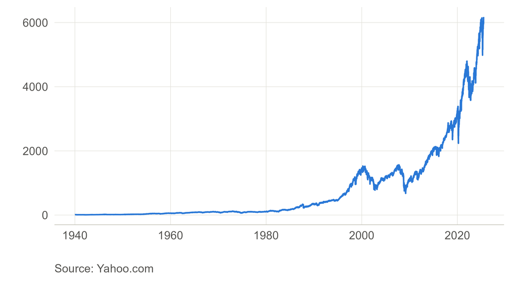

### Le même indice, à deux échelles

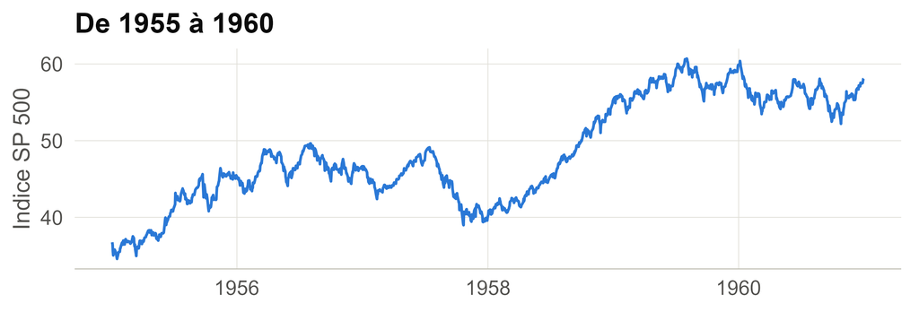

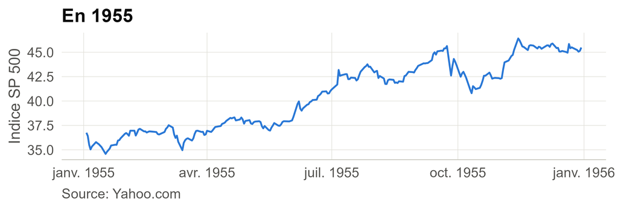

### Une théorie qui a transformé la finance

**Cette théorie n’est pas restée à l’université.**

- Les pionners de la gestion indicielle moderne comme Jack Bogle ou John McQuown ont appliqué cette théorie en créant leurs premiers fonds d’investissement.
- Ces fonds sont devenus Vanguard et Black Rock qui gère respectivement 12 000 milliards et 14 000 millards.

Mais cette théorie est muette sur les nombreuses crises financières qui marquent l’histoire économique.

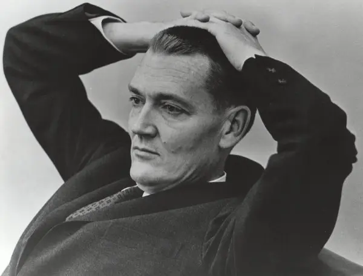

Jack Bogle (1929-2019), fondateur de Vanguard

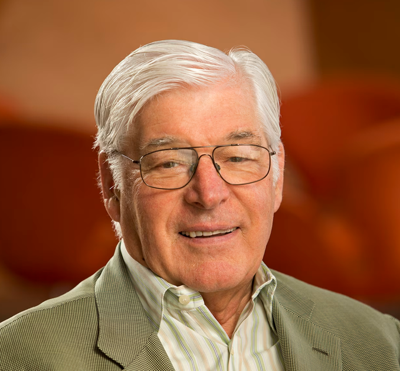

John McQuown (1934-2022), fondateur du premier fond indicielle

### Qu’est-ce qu’une crise financière ?

**Définitions**

- Une crise financière est une perturbation majeure d’un ou de marchés financiers. Elle se caractérise généralement par une augmentation des faillites, une perte de confiance des investisseurs dans le futur et donc une baisse du financement de l’économie.
- Une bulle financière est une métaphore qui désigne une hausse jugée trop importante du prix d’un actif, ou d’un ensemble d’actifs. La réalisation de la hausse jugée trop importante entraîne un effondrement brutale du prix de l’actif (“éclatement”).

Source : Kindleberger, Charles P. (1978). *Manias, Panics, and Crashes: A History of Financial Crises*. New York: Basic Books.

### Le prix et sa valeur

Une bulle est facile à définir mais difficile à identifier et à prédire.

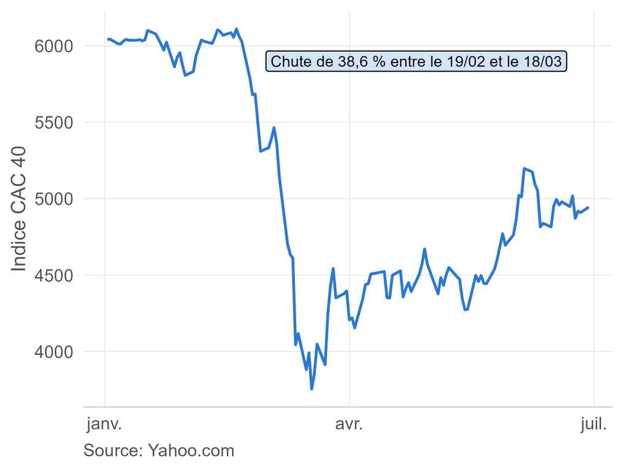

Le CAC 40 lors du premier confinement en 2020

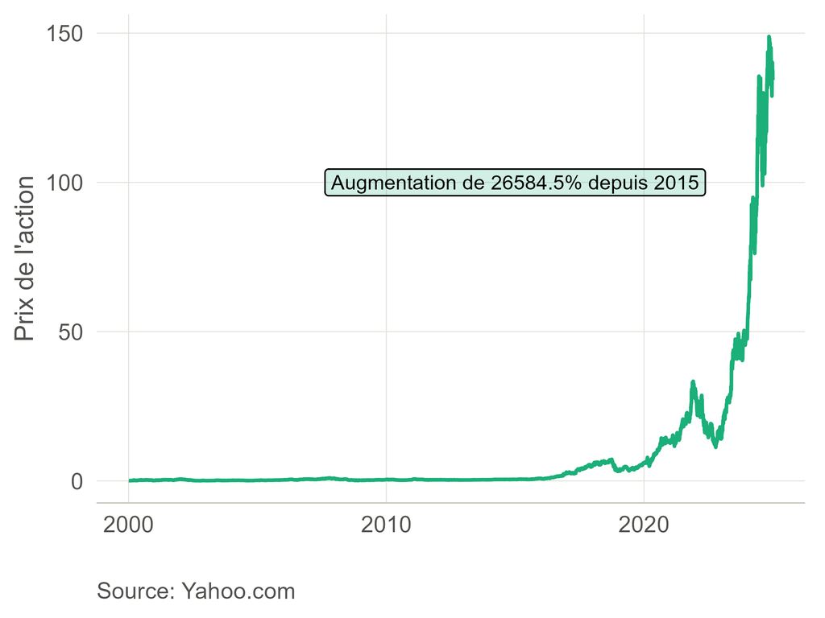

Evolution du prix de l’action NVDIA

### Prix et valeur

La valeur d’un actif, c’est ce qu’il rapporte dans le futur. L’évaluer demande **deux** opérations, et aucune des deux n’est facile.

$$P_t = \frac{F_{t+1}}{(1+r)} + \frac{F_{t+2}}{(1+r)^2} + \dots + \frac{F_{t+n}}{(1+r)^n}$$

**1. Anticiper les flux $F_{t:t+n}$**

- Combien l’actif rapportera, chaque année, et pendant combien de temps ?
- Ce sont des prévisions d’un futur par nature incertain, pas des données.

**2. Les actualiser $(1+r)^n$**

- Rappel chapitre 1: un euro futur vaut moins qu’un euro actuel
- Le taux d’actualisation reflète le coût du risque et du temps
- Même si j’anticipe correctement, quel est la prime $r$ pour le risque que je prend ?

### Exemples de crises financières dans l’histoire

- La crise des tulipes (1637) ;
- L’hyperinflation de la République de Weimar (1923) ;
- Le krach de Wall Street (1929) ;
- La crise asiatique (1997) ;
- La bulle internet (2000) ;
- La crise des subprimes (2007-2008) ;

[figure not shown]

Tulipe *Semper augustus*

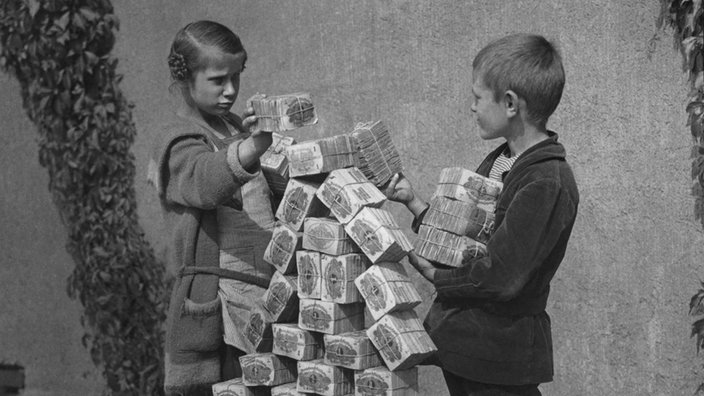

Des enfants allemands jouent avec des billets de marks en 1923

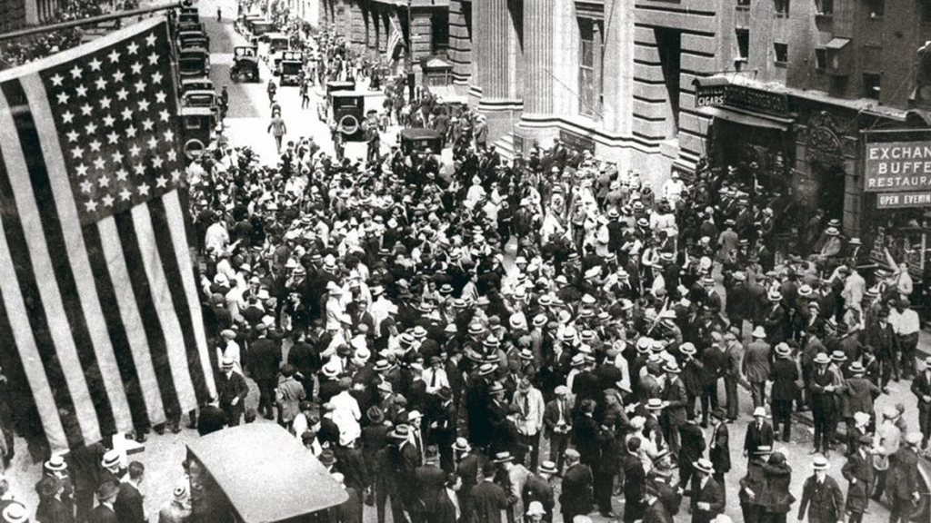

Une foule s’ammasse à Wall Street le jeudi “noir” du 24 octobre 1929

[figure not shown]

La masquotte de l’entreprise Pets.com

[figure not shown]

Une panique bancaire devant une enseigne de Northern Rock en Angleterre

### La bulle internet

[figure not shown]

[figure not shown]

[figure not shown]

- Kozmo et Webvan : livraison de produits en moins d’une heure ;
- Pets.com : vente en ligne de produits pour animaux ;
- Après avoir levé des centaines de millions de dollars, elles font faillite en quelques mois en 2000-2001.

Pástor et Veronesi. (2006). Was there a Nasdaq bubble in the late 1990s?, Journal of Financial Economics, 81(1), p. 61-100

### La bulle internet

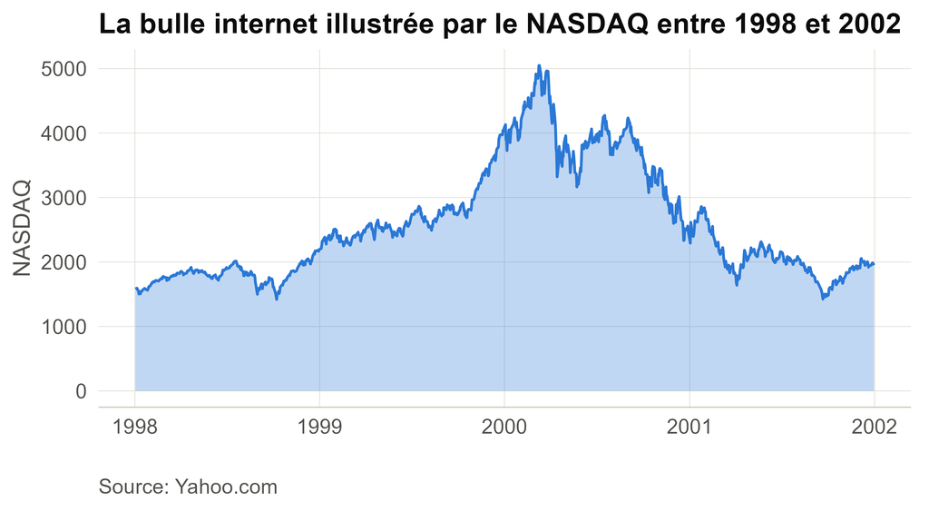

### Comment expliquer ces emballements spéculatifs ?

**Le concours de beauté de John Maynard Keynes**

Les joueurs doivent choisir les six visages les plus jolis entre des centaines de photographies. Le gagnant est celui qui s’approche le plus de la moyenne de l’ensemble des joueurs.

Comment optimiser ces chances de gagner ?

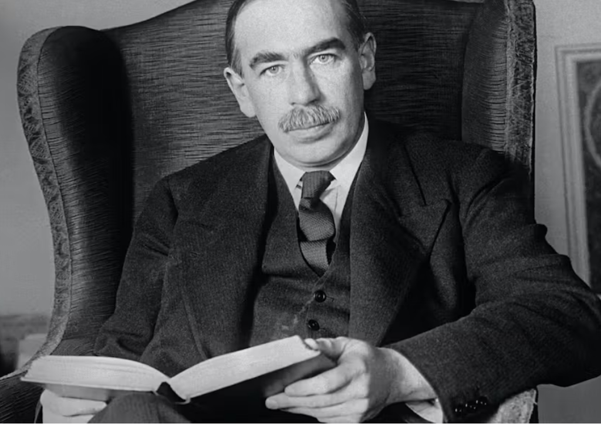

L’économiste John Maynard Keynes (1889-1946)

Le prix d’un actif est une construction collective, l’actif dépend non seulement de la valeur intrinsèque que je lui attribue, mais aussi de la valeur que le reste de la société lui attribue.

Source : Keynes (1936, chap. 12) ; Orléan (1999)

### Les phases d’une bulle financière

1. 😃 La convention optimiste
2. 😕 Le retournement de l’opinion
3. 😱 La convention pessimiste
- Optimisme généralisé
  - Exogène (“nouvelle ère”, “révolution”, “disruption”).
  - Endogène (de bonnes performances passées augmentent la prise de risque)
- L’optimisme se renforce de lui-même à travers plusieurs mécanismes:
  - Mimétisme concurrentiel
  - Effet de levier
  - Prophétie autoréalisatrice
- Apparition de signes de faiblesse économique:
  - Ralentissement de la dynamique (croissance, emploi, investissement, etc.)
  - Signes croissant de fragilités financières (défauts de paiement, illiquidité, etc.)
- Les individus vendent massivement et cherchent de la liquidité.
- Inversion des mécanismes de la phase optimiste:
  - Le mimétisme devient un mimétisme pessimiste.
  - Les effets de levier se retournent contre les endettés.
  - La chute des prix devient une prophétie autoréalisatrice.

### Synthèse du chapitre

- **Efficience des marchés financiers:** le prix agrège l’information dispersée — il est difficile de battre le marché.
- **Ce qu’elle n’explique pas:** la récurrence des crises qui marque le XXe siècle.
- **Crise financières:** définitions — exemples historiques.
- **Explications d’une bulle**: mimétisme concurrentiel — effet de levier — prophétie autoréalisatrice.

### Wooclap de fin de chapitre

### Références

Keynes, John Maynard. 1936. *The General Theory of Employment, Interest and Money*. London: Macmillan.

Kindleberger, Charles P. 1978. *Manias, Panics, and Crashes: A History of Financial Crises*. New York: Basic Books.

Orléan, André. 1999. *Le pouvoir de la finance*. Paris: Odile Jacob.

Pástor, Luboš, et Pietro Veronesi. 2006. « Was there a Nasdaq bubble in the late 1990s? » *Journal of Financial Economics* 81 (1): 61‑100. https://doi.org/10.1016/j.jfineco.2005.05.009.